# Comment poser du secret sur des tableaux à 4 ou 5 dimensions avec `rtauargus`?

[figure not shown]

Les algorithmes de pose du secret secondaire tels qu’Optimal ou Modular implémentés dans `Tau-Argus` reposent sur un programme d’optimisation sous contraintes. Le nombre de ces contraintes devient très difficile à gérer - du moins dans un temps raisonnable - pour `Tau-Argus`. La pose du secret sur un tableau à 5 dimensions directement avec `Tau-Argus` est impossible et les résultats fournis par le logiciel lors du traitement d’un tableau de 4 dimensions sont accompagnés d’un avertissement. Par ailleurs, un tableau à 4 dimensions dont l’une est hiérarchique est un problème, en général, très difficile pour `Tau-Argus`.

Le package `rtauargus` offre désormais la possibilité de protéger des tableaux de 4 à 5 dimensions. Pour les tableaux de 4 dimensions, la protection est même plus rapide et permet de traiter des tableaux plus grands encore (en nombre de lignes). Certains tableaux demeurent néanmoins trop complexes pour `Tau-Argus`.

Cette nouvelle fonctionnalité est mise à disposition dans les fonctions `tab_rtauargus` et `tab_multi_manager` avec l’argument `split_tab`. Quand il est renseigné à `TRUE`, les fonctions réduisent la dimension d’un tableau de 4 ou 5 dimensions en construisant un certain nombre de tableaux liés de 3 dimensions chacun. Ces tableaux contiennent exactement les mêmes cellules que le tableau original. Puis, la fonction `tab_multi_manager` est appelée pour organiser la pose du secret sur l’ensemble de ces tableaux. À la fin du processus, on récupère la table de départ - avec ses dimensions originales - augmentée des informations sur le secret secondaire.

Ainsi, point important à retenir, la pose du secret secondaire est toujours réalisée par les algorithmes de `Tau-Argus`, le package `rtauargus` ne fait que découper le tableau en sous-tableaux à trois dimensions et assurer la cohérence du secret entre ces différents sous-tableaux liés entre eux.

Cette méthode est susceptible de générer plus de secret qu’une attaque directe du problème. Mais celle-ci étant impossible dans les cas visés, c’est un moindre mal.

Pour utiliser cette fonctionnalité, il est nécessaire que l’utilisateur pose de lui-même le secret primaire en amont.

## 1 Comment la réduction d’un tableau à 4 ou 5 dimensions est-elle réalisée ?

Pour passer de 5 à 3 dimensions, on utilise deux fois de suite la méthode utilisée pour réduire un tableau en sous-tableaux ayant une dimension de moins.

Le passage de 4 à 3 dimensions consiste d’abord à fusionner deux des quatre dimensions du tableau original, c’est-à-dire qu’on remplace deux des variables de départ par une seule dont les modalités sont la fusion des modalités des deux variables choisies.

Dans l’exemple ci-dessous, on fusionne par exemple les deux variables `SEX` et `AGE` pour n’en faire qu’une seule appelée `SEX_AGE`.

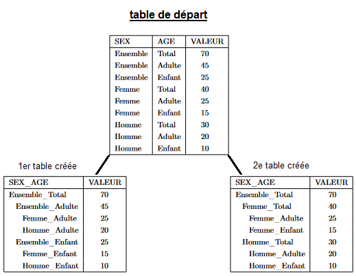

Mais, la nouvelle variable contient des modalités non-emboîtées entre elles, comme, par exemple, les modalités `Femme_Total` et `Ensemble_Adulte`.

```
Total_Ensemble = Total_Adulte + Total_Enfant
```

```
Total_Ensemble = Femme_Ensemble + Homme_Ensemble
```

Or, nous savons gérer la présence de hiérarchies non-emboîtées dans un tableau. Il suffit, en effet, de construire les sous-tableaux de même structure de telle sorte que dans chacun de ces sous-tableaux la variable incriminée soit restreinte à une partie parfaitement emboîtée de ses modalités. Pour poser le secret sur les sous-tableaux liés engendrés, il est fait appel à la fonction `tab_multi_manager`, spécialement conçue pour assurer la cohérence du secret entre tableaux liés.

Ici, la fusion nécessite la construction de deux sous-tableaux, chacun ayant une variable `SEX__AGE` parfaitement hiérarchique. Le premier rassemble les modalités `Total_Ensemble`, `Total_Adulte` et `Total_Enfant`, le second `Total_Ensemble`, `Femme_Ensemble` et `Homme_Ensemble`.

Cet exemple est le plus simple qu’il soit: en fusionnant deux variables non hiérarchiques, on est amené à générer deux sous-tableaux.

Lorsque l’une des variables fusionnées est elle-même hiérarchique, la construction des sous-tableaux s’appuie sur les différents sous-totaux présents dans la hiérarchie, comme indiqué dans la figure ci-dessous:

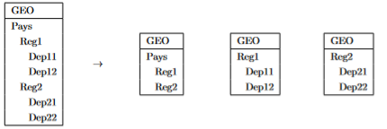

## 2 Pour aller plus loin

- [Article présentant la méthode et des résultats de simulation](https://github.com/InseeFrLab/dims_reduction_tables_workshop_20231215)

## 3 Les principaux arguments ajoutés à `tab_rtauargus()` et `tab_multi_manager()`

Pour activer le découpage des tableaux de dimension 4 ou 5 en sous-tableaux de 3 dimensions, l’utilisateur doit activer l’argument `split_tab = TRUE` (valeur par défaut). L’utilisateur veillera à passer cet argument à `FALSE` s’il souhaite qu’un tableau à 4 dimensions soit traité directement par `Tau-Argus`.

L’argument `nb_tab_option` permet de préciser la façon dont le tableau est découpé :

- **`nb_tab_option = "smart"` (option recommandée et par défaut) :** Cherche à générer le minimum de sous-tableaux tout en cherchant à respecter une taille maximale de sous-tableau fixée par l’argument `limit`. Si `limit = NULL` (valeur par défaut), une limite intermédiaire est calculée automatiquement via la fonction `auto_limit()`.
- **`nb_tab_option = "min"` :** Construit le minimum absolu de sous-tableaux à 3 dimensions, sans contrainte sur la taille des sous-tableaux produits.
- **`nb_tab_option = "max"` (déconseillée) :** Tente de construire le maximum de sous-tableaux possible. Cette option génère un sur-secret important et est aujourd’hui déconseillée au profit de l’option `"smart"`.

> 💡 **Pour en savoir plus sur le fonctionnement détaillé de ces options, l’impact sur le temps de calcul et le choix de la valeur de `limit`, consultez la section Comment choisir le nombre de tableaux à générer lors de la réduction de dimension ? en fin de vignette.**

## 4 Exemple

Comme tout est géré par la fonction `tab_rtauargus`, la pose du secret sur un tableau à 4 ou 5 dimensions n’ajoute pas de difficultés particulières pour l’utilisateur en réalité.

Nous présentons ici un exemple de pose de secret sur un tableau à 4 dimensions.

> ⚠️ **Avertissement concernant les temps d’exécution**

> Des optimisations majeures ont été apportées à la fonction `tab_multi_manager()` (utilisée lors du traitement des tableaux issus de la réduction de dimension) avec la version 1.3.5 de rtauargus publié à l’été 2026. Ainsi, si vous avez utilisé cette fonctionnalité par le passé, les performances ressenties côté utilisateur peuvent radicalement changer.

### 4.1 Préparation des données

```r
library(tictoc)
library(dplyr)
library(rtauargus)
```

```r
options(
  rtauargus.tauargus_exe =
    "Y:/Logiciels/TauArgus/TauArgus4.2.3/TauArgus.exe"
)
```

```r
data("datatest1")
str(datatest1)
```

```
#> tibble [689 x 12] (S3: tbl_df/tbl/data.frame)
#>  $ treff         : chr [1:689] "tr1" "tr2" "tr3" "Total" ...
#>  $ cj            : chr [1:689] "Total" "Total" "Total" "PA" ...
#>  $ type_distrib  : chr [1:689] "Total" "Total" "Total" "Total" ...
#>  $ A10           : chr [1:689] "Total" "Total" "Total" "Total" ...
#>  $ nb_obs        : num [1:689] 227093 7803 227 1443 125904 ...
#>  $ pizzas_tot    : num [1:689] 5900938 6538420 6794859 15128 10168928 ...
#>  $ pizzas_max    : num [1:689] 135444 267177 852749 2756 523505 ...
#>  $ is_secret_freq: logi [1:689] FALSE FALSE FALSE FALSE FALSE FALSE ...
#>  $ is_secret_dom : logi [1:689] FALSE FALSE FALSE FALSE FALSE FALSE ...
#>  $ is_secret_prim: logi [1:689] FALSE FALSE FALSE FALSE FALSE FALSE ...
#>  $ nb_obs_rnd    : num [1:689] 227094 7804 228 1444 125905 ...
#>  $ pizzas_tot_abs: num [1:689] 5900938 6538420 6794859 15128 10168928 ...
#>  - attr(*, ".internal.selfref")=<externalptr>
```

### 4.2 Préparation des arguments pour `tab_rtauargus`

```r
totcode <- c(treff ="Total",cj ="Total", A10 = "Total", type_distrib ="Total")
explanatory_vars<- names(totcode)
```

### 4.3 Pose du secret primaire

```r
datatest1_with_prim <- datatest1 %>%
    mutate(
      is_secret_freq = (nb_obs > 0 & nb_obs < 3),
      is_secret_dom = (pizzas_tot != 0) & (pizzas_max > 0.85*pizzas_tot),
      pizzas_tot= round(abs(pizzas_tot),2)
    ) %>%
    mutate(
      is_secret_prim =  is_secret_freq ,
      nb_obs = ceiling(nb_obs)
    )
```

### 4.4 Pose du secret secondaire avec `rtauargus`

Pour poser le secret secondaire, on utilise la fonction `tab_rtauargus` avec l’argument `split_tab = TRUE`. Ainsi, `Tau-Argus` n’aura pas à traiter directement le secret sur la table à 4 dimensions. La fonction `tab_rtauargus` va découper la table originale en un certain nombre de tables qui seront protégées comme des tables liées avec un appel sous-jacent à `tab_multi_manager`.

```r
tictoc::tic()
res_wi_split <- tab_rtauargus(
    tabular = datatest1_with_prim,
    files_name = "datatest1",
    dir_name = "example_1",
    explanatory_vars = explanatory_vars,
    totcode = totcode,
    value = "pizzas_tot",
    freq = "nb_obs",
    secret_var = "is_secret_prim",
    verbose = TRUE,
    split_tab = TRUE
)
```

```
#>
#> Reducing dims...
#>  tab
#>
#> Choosing variables...
#>
#> Reducing from 4 to 3...
#> tab has generated 2 tables in total
#>
#>   Table size distribution :
#>    Min. 1st Qu.  Median    Mean 3rd Qu.    Max.
#>   535.0   536.5   538.0   538.0   539.5   541.0
#>
#>
#>
```

```r
--- Current table to treat: tab1 | loop iter : 1 ---
--- Current table to treat: tab2 | loop iter : 2 ---
--- Current table to treat: tab1 | loop iter : 3 ---
--- Current table to treat: tab2 | loop iter : 4 ---
--- Current table to treat: tab1 | loop iter : 5 ---
tictoc::toc()
```

```
#> 61.37 sec elapsed
```

La réduction de dimensions a conduit à construire deux sous-tableaux de 3 dimensions à partir du tableau original.

```r
str(res_wi_split)
```

```
#> 'data.frame':    689 obs. of  13 variables:
#>  $ treff         : chr  "tr1" "tr2" "tr3" "Total" ...
#>  $ cj            : chr  "Total" "Total" "Total" "Total" ...
#>  $ type_distrib  : chr  "Total" "Total" "Total" "2" ...
#>  $ A10           : chr  "Total" "Total" "Total" "Total" ...
#>  $ nb_obs        : num  227094 7804 228 77736 110405 ...
#>  $ pizzas_tot    : num  5900938 6538420 6794859 6692768 9280934 ...
#>  $ pizzas_max    : num  135444 267177 852749 852749 523505 ...
#>  $ is_secret_freq: logi  FALSE FALSE FALSE FALSE FALSE FALSE ...
#>  $ is_secret_dom : logi  FALSE FALSE FALSE FALSE FALSE FALSE ...
#>  $ is_secret_prim: logi  FALSE FALSE FALSE FALSE FALSE FALSE ...
#>  $ nb_obs_rnd    : num  227094 7804 228 77736 110405 ...
#>  $ pizzas_tot_abs: num  5900938 6538420 6794859 6692768 9280934 ...
#>  $ is_secret_5   : logi  FALSE FALSE FALSE FALSE FALSE FALSE ...
```

```r
stats_wi_split <- res_wi_split %>%
    rename_with( ~"final_suppress", last_col()) %>%
    mutate(
      flag = case_when(
        is_secret_freq ~ "A",
        is_secret_dom ~ "B",
        final_suppress ~ "D",
        TRUE ~"V"
      )
    ) %>%
    count(flag)
stats_wi_split
```

```
#>   flag   n
#> 1    A  79
#> 2    B  35
#> 3    D 278
#> 4    V 297
```

Avec l’option de découpage du tableau de départ, la pose du secret sur le tableau à 4 dimensions génère 278 suppressions secondaires.

### 4.5 Comparaison avec une pose du secret sans réduire la dimension de la table

`Tau-Argus` est en capacité de poser le secret secondaire sur un tableau à 4 dimensions avec `Modular`, mais, en plus d’émettre un avertissement sur le fait qu’avec ce nombre de dimensions, la qualité du résultat n’est pas garantie, il est aussi beaucoup plus long à poser le secret secondaire que lorsqu’il traite deux tables liées issues du tableau original.

```r
tictoc::tic()
res_wo_split <- tab_rtauargus(
    tabular = datatest1_with_prim,
    files_name = "datatest1",
    dir_name = "example_1/wo_split",
    explanatory_vars = explanatory_vars,
    totcode = totcode,
    value = "pizzas_tot",
    freq = "nb_obs",
    secret_var = "is_secret_prim",
    verbose = TRUE,
    split_tab = FALSE
)
```

```
#> Warning :
#> It is highly recommended to use split_tab = TRUE when using rtauargus with 4 or 5 dimensions tables.
#> It allows to split the table in several tables with 3 dimensions.
#>
#> With split_tab = FALSE, tauargus treats the table in 4 or 5 dimensions.
#> In this case, the secondary secret may not being optimal according to tauargus itself
#> and the process may take longer.
#> Start of batch procedure; file: Z:\rtauargus\vignettes\example_1\wo_split\datatest1.arb
#> <OPENTABLEDATA> "Z:\rtauargus\vignettes\example_1\wo_split\datatest1.tab"
#> <OPENMETADATA> "Z:\rtauargus\vignettes\example_1\wo_split\datatest1.rda"
#> <SPECIFYTABLE> "treff""cj""A10""type_distrib"|"pizzas_tot"||
#> <SAFETYRULE> MAN(10)
#> <READTABLE> 1
#> Tables have been read
#> <APRIORI> "Z:\rtauargus\vignettes\example_1\wo_split\datatest1.hst",1,",",0,0
#> Apriory file: Z:\rtauargus\vignettes\example_1\wo_split\datatest1.hst has been applied
#>                    to table: treff x cj x A10 x type_distrib | pizzas_tot
#> Apriori file Z:\rtauargus\vignettes\example_1\wo_split\datatest1.hst has been read
#> <SUPPRESS> MOD(1,5,1,0,0)
#> Start of the modular protection for table treff x cj x A10 x type_distrib | pizzas_tot
#> WARNING: The table has 4 dimensions.
#>                    Running Modular can take a lot of time and maybe it is difficult to obtain a correct result.
#>                    Please check the results carefully.
#>
#> End of modular protection. Time used 300 seconds
#>                    Number of suppressions: 289
#> <WRITETABLE> (1,4,,"Z:\rtauargus\vignettes\example_1\wo_split\datatest1.csv")
#> Table: treff x cj x A10 x type_distrib | pizzas_tot has been written
#>                    Output file name: Z:\rtauargus\vignettes\example_1\wo_split\datatest1.csv
#> End of TauArgus run
```

```r
tictoc::toc()
```

```
#> 307.9 sec elapsed
```

Avec seulement 689 lignes et aucune variable hiérarchique, la pose directe du secret prend environ 5 minutes à `Tau-Argus`.

```r
stats_wo_split <- res_wo_split %>%
    mutate(
      flag = case_when(
        is_secret_freq ~ "A",
        is_secret_dom ~ "B",
        TRUE ~ Status
      )
    ) %>%
    count(flag)
stats_wo_split
```

```
#>   flag   n
#> 1    A  79
#> 2    B  35
#> 3    D 266
#> 4    V 309
```

La pose directe du secret sur le tableau à 4 dimensions génère 266 suppressions secondaires.

On peut observer que le traitement de la table à 4 dimensions directement génère un masque un peu moins chargé en secret: 266 cellules en secret secondaire, contre 278 avec une réduction de dimensions.

Il est difficile d’anticiper cette différence puisqu’elle est très dépendante de la structuration des données, de la présence du secret primaire au sein du tableau original et de la façon dont les sous-tableaux vont être construits.

## 5 Choix avancé du nombre de tableaux et paramétrage de `limit`

### 5.1 Comment choisir le nombre de tableaux à générer lors de la réduction de dimension ?

Lors de la réduction de dimension, il est possible de choisir plusieurs valeurs pour l’argument `nb_tab_option`.

De manière historique, les options `"min"` et `"max"` ont été créées pour générer respectivement le minimum ou le maximum de sous-tableaux via le choix des variables à fusionner.

L’option `"smart"` a été développée par la suite et constitue **la valeur recommandée en pratique**. Elle calcule, pour chaque possibilité de variables à fusionner, le nombre de tableaux qui seront générés ainsi que leurs tailles. Elle s’utilise conjointement avec l’argument `limit`, qui fixe une taille maximale théorique par sous-tableau. Par défaut (`limit = NULL`), `rtauargus` détermine automatiquement une valeur intermédiaire optimale grâce à `auto_limit()`. L’utilisateur peut également fixer manuellement cette limite s’il le souhaite (par exemple `limit = 20000L`).

L’option `"smart"` cherche à fusionner les variables de manière à **minimiser le nombre de tableaux générés**, sous la contrainte que chaque tableau ait une taille inférieure à `limit` (si possible).

> 💡 **Remarque mathématique sur l’exploration des combinaisons :**

> Pour réduire un tableau de 4 à 3 dimensions en fusionnant deux variables, il existe 6 combinaisons de fusions possibles (ce qui correspond au [nombre de Stirling de seconde espèce](https://fr.wikipedia.org/wiki/Nombre_de_Stirling#Nombre_de_Stirling_de_seconde_esp%C3%A8ce) *S*(4, 3) = 6).

> Pour passer directement de 5 à 3 dimensions, ce nombre s’élève à *S*(5, 3) = 25 combinaisons.

> La fonction `explore_reduce_dims()` évalue analytiquement l’ensemble de ces combinaisons (6 en 4D, 25 en 5D) sans générer de fichiers ni lancer *Tau-Argus*, afin de vous aider à retenir le découpage le plus judicieux.

#### 5.1.1 Exemple d’exploration sur un tableau 5D

```r
library(rtauargus)

load("../data/input_data_5d.RData") # dfs5_agg, tot5, hrc5

dfs5_agg %>% colnames() %>% print()
```

```
#> [1] "ACT"            "GEO"            "SEX"
#> [4] "AGE"            "ECO"            "VALUE"
#> [7] "is_secret_prim" "secret_no_pl"   "freq"
```

```r
dfs5_agg %>% dplyr::tally() %>% print()
```

```
#>        n
#> 1 475200
```

```r
# ======================================================================
# Détail des modalités par variable (Totaux inclus) :
#  - ACT : 25 modalités (1 Total + 4 groupes + 20 sous-niveaux)
#  - GEO : 36 modalités (1 Total + 5 régions + 30 sous-régions)
#  - SEX : 11 modalités (1 Total + 10 modalités fines)
#  - AGE : 16 modalités (1 Total + 15 modalités fines)
#  - ECO :  3 modalités (1 Total +  2 modalités fines)
# ======================================================================

explore_reduce_dims(dfs = dfs5_agg,
                    totcode = tot5,
                    hrcfiles = hrc5)
```

```
#>    nb_tab nb_hrc min_size med_size max_size
#> 1      20      3    63756    77688    95616
#> 2      20      3    53460    73494   101016
#> 3      20      3    53820    75348   101556
#> 4      24      3    52325    63325    78850
#> 5      24      3    46200    61488    81650
#> 6      24      3    46575    61862    82150
#> 7      54      3    20700    27900    41400
#> 8     120      2     9856    14768    18176
#> 9     120      2     9200    13616    18352
#> 10    120      2    12075    17630    18426
#> 11    120      2     9360    14640    18544
#> 12    120      2     9801    15158    18656
#> 13    120      2     9075    13431    18722
#> 14    120      2     9295    15015    19019
#> 15    120      2    10920    16953    19383
#> 16    120      2    10935    17202    19398
#> 17    168      2     6336     9216    17856
#> 18    214      2     5200     7600    12400
#> 19    218      2     4356     6336    18216
#> 20    270      2     4860     6588     9828
#> 21    274      2     3575     5225    12650
#> 22    324      2     4200     5325     7950
#> 23    758      1     1936     2640     3344
#> 24   1070      1     1200     1776     2928
#> 25   1370      1      825     1221     3003
```

Par exemple, dans l’exemple ci-dessous, entre 20 et 54 tables, les sous-tables ont 3 variables hierarchiques ; entre 120 et 324 sous tables, 2 variables hierarchiques ; et de 758 à 1370 tables, 1 variable hierarchique.

Intuitivement, au vu des tailles de tables, la configuration à 120 sous-tables peut sembler être un bon compromis initial pour réduire le nombre de variables hiérarchiques. Néanmoins, comme nous le verrons dans le benchmark ci-dessous, l’impact sur le secret secondaire et le temps de calcul varie fortement selon la dimension et le solveur retenu.

De manière empirique, on pourrait ensuite éventuellement tester d’autres configurations (par exemple 54 sous-tables, 168 et 270 sous-tables) afin de voir si d’autres configuration peuvent nous apporter un meilleur secret, ou un temps d’éxécution plus raisonnable.

## 6 Benchmarks de performance (4D et 5D)

### 6.1 Résultats sur un tableau à 4 dimensions

D’un point de vue méthodologique, on peut se demander quel est l’impact de `limit` sur le nombre de tables, le temps d’éxecution, ainsi que le secret généré. Ci-dessous une synthèse sur une table à 4 dimensions est proposée.

#### 6.1.1 Table initiale 4D

```
======================================================================
Nombre de lignes de la table : 124800
Détail des modalités par variable (Totaux inclus) :
  - ACT : 65 modalités (1 Total + 8 groupes + 8 * 7 sous-niveaux)
  - GEO : 64 modalités (1 Total + 7 régions + 7 * 8 sous-régions)
  - SEX : 6 modalités (1 Total + 5 modalités fines)
  - AGE : 5 modalités (1 Total + 4 modalités fines)
======================================================================
```

La table contient 9.8% de secret primaire.

#### 6.1.2 Résultats avec la méthode **HYPERCUBE** (`GH(1,100)`)

| Variant | Nb tables | Taille max (lignes) | Temps d’exéc. | Mémoire max | % cellules masquées | % valeur masquée |
| --- | --- | --- | --- | --- | --- | --- |
| **`no_split`** *(sans réduction)* | 1 | 124 800 | 2min 55s (175 s) | NA | 26,60 % | 1,28 % |
| **`min`** | 2 | 108 160 | 10min 06s (606 s) | 521,8 MB | 28,40 % | 1,34 % |
| **`smart_108000`** | 16 | 15 925 | 12min 46s (766 s) | 451,6 MB | 25,58 % | 1,19 % |
| **`smart_15800`** | 18 | 15 680 | 12min 22s (742 s) | 384,4 MB | 25,84 % | 1,20 % |
| **`smart_15600`** | 144 | 2 190 | 30min 37s (1 837 s) | 640,2 MB | 24,14 % | 1,11 % |

#### 6.1.3 Résultats avec la méthode **MODULAR** (`MOD(1,5,1,0,0)`)

| Variant | Nb tables | Taille max (lignes) | Temps d’exéc. | Mémoire max | % cellules masquées | % valeur masquée |
| --- | --- | --- | --- | --- | --- | --- |
| **`no_split`** *(sans réduction)* | 1 | 124 800 | 4h 42min 05s (16 925 s) | NA | 21,61 % | 0,95 % |
| **`min`** | 2 | 108 160 | 3h 28min 33s (12 513 s) | 602,1 MB | 21,95 % | 0,92 % |
| **`smart_108000`** | 16 | 15 925 | 17min 49s (1 069 s) | 381,9 MB | 19,55 % | 0,81 % |
| **`smart_15800`** | 18 | 15 680 | 19min 21s (1 161 s) | 420,3 MB | 19,83 % | 0,82 % |
| **`smart_15600`** | 144 | 2 190 | 30min 12s (1 812 s) | 651,9 MB | 18,07 % | 0,74 % |

> 💡 **Remarque sur le choix automatique du paramètre par défaut (`limit = NULL`) :**

> Sur ce tableau 4D, laisser `limit = NULL` amène la fonction `auto_limit()` à choisir automatiquement la valeur de **15 925 lignes**, ce qui correspond au scénario à **16 tableaux**.

> Ce choix automatique ne donne pas forcément le résultat optimal absolu (dans cet exemple, la variante à 144 tableaux permet de masquer environ 1,5 point de cellules en moins), mais il offre **un compromis intermédiaire très robuste** :
> - **Il évite un nombre insuffisant de tableaux** (scénarios 1 ou 2 tables) qui ferait s’éterniser le calcul dans Tau-Argus (3h30 à 4h40) voire bloquerait le solveur ;
> - **Il évite à l’inverse le sur-découpage** (plusieurs centaines de tables) qui deviendrait lourd en gestion de fichiers I/O et itérations de réconciliation ;
> - **Il garantit une exécution rapide** (~17 minutes) et fiable, sans nécessiter de réglage manuel préalable de la part de l’utilisateur.

#### 6.1.4 Enseignements pour le cas 4 dimensions

L’analyse détaillée des résultats apporte des éclairages méthodologiques cruciaux sur le fonctionnement combiné de `rtauargus` et de `Tau-Argus` :

##### 6.1.4.1 Découpage par `rtauargus` vs décomposition interne de `Tau-Argus`

En mode direct (`split_tab = FALSE`), la méthode `Modular` tente de décomposer la table 4D en sous-problèmes en interne dans `Tau-Argus`. Pour un tableau intégrant deux hiérarchies complexes, cette structuration interne est extrêmement lourde et demande un temps de calcul considérable (**4h 42min**).

À l’inverse, la réduction de dimension effectuée en amont par `rtauargus` (`reduce_dims`) est **quasi instantanée (~5 secondes)**. Elle soulage `Tau-Argus` en lui transmettant directement des sous-tables 3D indépendantes et liées.

##### 6.1.4.2 Convergence du solveur et répartition du secret primaire

Deux mécanismes expliquent la baisse du temps de calcul et l’amélioration de la qualité du secret lors du découpage :

- **Convergence facilitée :** Sur des sous-tables plus petites et comportant moins de variables (1 ou 2 variables hiérarchiques), le solveur de programmation linéaire convergera plus facilement et rapidement vers la solution optimale, réduisant ainsi le sur-masquage.
- **Isolement du secret primaire :** Seule une fraction des sous-tables générées contient réellement des cellules en secret primaire (les sous-tables regroupant des grands totaux ou sous-totaux élevés en sont souvent exemptes). `Tau-Argus` traite les tables sans secret primaire de manière quasi immédiate. Ainsi, multiplier le nombre de tables n’accroît pas le temps de calcul de façon linéaire, et évite de propager du secret secondaire sur des sous-espaces de la table qui n’en ont pas besoin.

##### 6.1.4.3 Avertissement : attention au sur-découpage

Dans ce benchmark, le cas à **144 tables (`smart_15600`)** donne de très bons résultats en terme de qualité du secret (18,07 % de masquage), car les sous-tables sont très petites et faciles à résoudre pour le solveur.

⚠️ **Il convient toutefois de rester raisonnable sur le nombre de sous-tableaux générés** (viser de quelques dizaines à une centaine de tables maximum). Sur des jeux de données plus volumineux, passer par exemple de 100 à 1 000 sous-tables deviendrait **contre-productif** :

- Le solveur n’obtiendra plus de gain notable sur la résolution individuelle de chaque table.
- La phase de réconciliation inter-tables (`tab_multi_manager`) devra effectuer de très nombreuses itérations, entraînant une **explosion du temps d’exécution** (coût de gestion des fichiers I/O).
- La sur-fragmentation peut faire perdre la vision globale au traitement et conduire à une **dégradation de la qualité du secret** (masques redondants posés par précaution entre sous-tables).

##### 6.1.4.4 Synthèse comparative

| Méthode & Option | Temps d’exécution | Qualité du secret (% masqué) | Bilan méthodologique |
| --- | --- | --- | --- |
| **`Hypercube` direct (`split_tab = FALSE`)** | **Très rapide** | Faible à moyenne | Le moyen le plus rapide de poser le secret, mais avec un sur-masquage plus important. |
| **`Modular` direct (`split_tab = FALSE`)** | **Extrêmement long** | Bonne | Qualité supérieure à Hypercube, mais le temps de calcul explose en 4D direct. |
| **`Modular` avec réduction (`split_tab = TRUE`)** | **Raisonnable** | **Excellente** | **Combinaison idéale** : le temps chute fortement et la qualité du secret est la meilleure de tous les cas. |

> 💡 **Message à retenir pour l’utilisateur**
> - **Si la qualité du secret est primordiale :** Privilégiez l’utilisation de **`Modular` avec `split_tab = TRUE`**. Le temps d’exécution s’abaisse à un niveau tout à fait raisonnable tout en offrant le meilleur masque de protection (perte d’information minimale).
> - **Si le temps d’exécution est votre contrainte principale :** Utilisez **`Hypercube` en direct (`split_tab = FALSE`)**. C’est l’option la plus rapide pour obtenir un tableau protégé, au prix d’un sur-masquage un peu plus élevé.

### 6.2 Résultats sur un tableau à 5 dimensions

> ⚠️ **`split_tab = TRUE` : Une fonctionnalité indispensable en 5 dimensions**

> Alors qu’un tableau à 4 dimensions peut encore être soumis (très lentement) directement à *Tau-Argus*, **la résolution directe d’un tableau à 5 dimensions est catégoriquement refusée par le logiciel**.

> L’utilisation de `split_tab = TRUE` ne constitue donc pas seulement une optimisation du temps de calcul : c’est la **seule et unique solution** permettant à `rtauargus` de protéger des tableaux de dimension 5.

#### 6.2.1 Table initiale 5D

[output not shown]

La table contient 9.5% de secret primaire.

#### 6.2.2 Résultats avec la méthode **HYPERCUBE** (`GH(1,100)`)

| Variant | Nb tables | Taille max (lignes) | Temps d’exéc. | Mémoire max (RAM) | % cellules masquées | % valeur masquée |
| --- | --- | --- | --- | --- | --- | --- |
| **`smart_100000`** | 20 | 95 616 | 1h 01min 56s *(3 716 s)* | 785,4 MB | 35,69 % | 1,40 % |
| **`smart_45000`** | 54 | 41 400 | 56min 27s *(3 387 s)* | 1 181,8 MB | 34,02 % | 1,32 % |
| **`smart_20000`** | 120 | 18 426 | 1h 29min 54s *(5 394 s)* | 2 057,7 MB | 30,77 % | 1,18 % |
| **`smart_18000`** | 168 | 17 856 | 1h 26min 01s *(5 161 s)* | 2 520,8 MB | 34,49 % | 1,36 % |
| **`smart_13000`** | 214 | 12 400 | 1h 29min 03s *(5 343 s)* | 3 085,4 MB | 34,00 % | 1,34 % |

#### 6.2.3 Résultats avec la méthode **MODULAR** (`MOD(1,5,1,0,0)`)

| Variant | Nb tables | Taille max (lignes) | Temps d’exéc. | Mémoire max (RAM) | % cellules masquées | % valeur masquée |
| --- | --- | --- | --- | --- | --- | --- |
| **`smart_100000`** | 20 | 95 616 | 1h 04min 37s *(3 877 s)* | 795,7 MB | 17,11 % | 0,49 % |
| **`smart_45000`** | 54 | 41 400 | 1h 55min 28s *(6 928 s)* | 1 285,3 MB | 24,17 % | 0,81 % |
| **`smart_20000`** | 120 | 18 426 | 1h 40min 46s *(6 046 s)* | 2 091,0 MB | 24,40 % | 0,83 % |
| **`smart_18000`** | 168 | 17 856 | 1h 43min 18s *(6 198 s)* | 2 570,1 MB | 24,49 % | 0,82 % |
| **`smart_13000`** | 214 | 12 400 | 2h 06min 56s *(7 616 s)* | 3 135,6 MB | 24,51 % | 0,82 % |

## 7 Synthèse et démarche recommandée (4D & 5D)

### 7.1 Pourquoi il n’existe pas de « recette miracle »

L’observation croisée des benchmarks 4D et 5D révèle un comportement en apparence contradictoire :

- **Sur le tableau 4D :** La variante à **144 sous-tables** (`smart_15600`) offre le masque le plus fin en *Modular* (18,07 % de masquage contre 21,61 % sans découpage).
- **Sur le tableau 5D :** C’est à l’inverse la variante à seulement **20 sous-tables** (`smart_100000`) qui l’emporte nettement (17,11 % de masquage contre 24,51 % avec 214 sous-tables), tout en s’exécutant deux fois plus vite.

### 7.2 Le compromis fondamental : Complexité locale vs Effet cascade inter-tables

Ce phénomène s’explique par l’arbitrage entre deux forces opposées :

- **La complexité du solveur local (*Tau-Argus*) :** Plus les sous-tables sont petites, plus les programmes d’optimisation linéaire sont simples à résoudre individuellement pour *Tau-Argus*. C’est ce qui rend le découpage fin très efficace dans le cas du tableau 4D.
- **L’effet cascade lors de la réconciliation (`tab_multi_manager`) :** En 5D, le passage de 5 à 3 dimensions tisse un réseau très dense de sous-tables interconnectées. Lorsqu’on découpe excessivement (ex: 214 tables), un secret posé dans une sous-table force la pose de masques secondaires dans d’autres sous-tables par ricochet lors de la phase de réconciliation. Cette propagation par cascade crée du **sur-masquage artificiel** (+7,4 points de secret) et multiplie les temps d’I/O et de traitement.

### 7.3 Comportement du choix automatique (`limit = NULL`)

L’argument `limit = NULL` fait appel à la fonction `auto_limit()`, qui calcule une valeur **médiane** intermédiaire :

- En 4D, cette médiane (16 tables) était plus conservatrice que l’optimum empirique (144 tables).
- En 5D, cette médiane (120 tables) entraînait à l’inverse un sur-découpage par rapport à l’optimum empirique (20 tables).

> ⚠️ **Prudence méthodologique : Ne pas faire de généralités**

> Ces tests reposent sur deux tableaux d’évaluation particuliers. **Il n’existe pas de paramètre universel ni de taille de table idéale valable pour tous les cas de figure.**

> La densité du secret primaire, la structure des hiérarchies et le nombre de dimensions modifient profondément l’équilibre entre la vitesse du solveur local et le coût de réconciliation inter-tables.

### 7.4 Démarche recommandée en pratique

Les expérimentations menées sur nos tableaux de test 4D et 5D démontrent qu’il **ne faut pas chercher systématiquement à générer le minimum absolu de sous-tableaux, ni tomber dans le sur-découpage**.

Le choix de la stratégie repose sur un compromis entre le solveur utilisé, la dimension du tableau et l’arbitrage entre vitesse et qualité du secret :

#### 7.4.1 Choix du solveur et de l’approche (`split_tab`)

- **Si la qualité du secret est primordiale :** Privilégiez **`Modular` avec `split_tab = TRUE`**.
  - En **4D**, le découpage permet généralement de réduire très nettement les temps de calcul par rapport au traitement direct sur les grands tableaux complexes, tout en préservant une excellente qualité de masque.
  - En **5D**, le découpage (`split_tab = TRUE`) est **obligatoire**, *Tau-Argus* refusant le traitement direct. Sur nos benchmarks, Modular s’est révélé particulièrement performant pour limiter le sur-masquage secondaire.
- **Si la vitesse absolue est votre seule contrainte :** Vous pouvez envisager **`Hypercube`**.
  - En **4D direct (`split_tab = FALSE`)**, c’est l’option la plus rapide pour obtenir un tableau protégé, mais elle s’accompagne en contrepartie d’un sur-masquage secondaire plus important.
  - En **5D**, l’utilisation d’Hypercube avec découpage reste très rapide, mais a tendance à générer davantage de secret secondaire que Modular.

#### 7.4.2 Choix de la taille de sous-tableaux (`limit`) et pièges à éviter

Le réglage du paramètre `limit` (qui fixe la taille maximale des sous-tables) doit être adapté selon le contexte :

- **En 4D :** Un découpage intermédiaire ou fin (réduisant les sous-tables à 1 ou 2 variables hiérarchiques) facilite la convergence du solveur local et permet souvent d’affiner le masque de secret.
- **En 5D :** La recherche du nombre optimal de sous-tables **n’est pas triviale** et dépend de la structure de vos données. Attention au sur-découpage massif (plusieurs centaines de tables) : lors de la phase de réconciliation inter-tables (`tab_multi_manager`), une fragmentation excessive peut provoquer une **propagation du secret par effet cascade**, augmentant le sur-masquage tout en alourdissant le temps de calcul et l’empreinte mémoire.

#### 7.4.3 Déroulé pas à pas pour l’utilisateur

Pour traiter vos tableaux en pratique :

1. **Explorer en amont avec `explore_reduce_dims()` (quasi instantané) :** Avant tout lancement de *Tau-Argus*, utilisez cette fonction pour visualiser les combinaisons de découpage analytiques. Observez le tableau récapitulatif (`nb_tab`, `nb_hrc`, `max_size`).
2. **Fixer le paramètre `limit` selon votre stratégie :**
   - **Mode automatique (`limit = NULL`) :** Recommandé pour une première exécution. La fonction `auto_limit()` sélectionne un compromis intermédiaire robuste sans réglage manuel.
   - **Mode manuel avec Modular :** Repérez dans les résultats d’exploration le palier qui offre un bon équilibre :
     - Évitez les sous-tables trop géantes (comportant plusieurs hiérarchies complexes et un grand nombre de lignes) qui pourraient faire peiner le solveur local.
     - Évitez la sur-fragmentation en plusieurs centaines de sous-tables pour prévenir l’effet cascade.
3. **Exécuter la protection avec `tab_rtauargus(split_tab = TRUE, limit = ...)`**.

## 8 Détail de la vignette

- Authors: **Wistan Pomel** & **Andre-Raymond Socard** & **Julien Jamme** & **Nathanael Rastout**
- Last update: **31/07/2026**
- Version of rtauargus used: **1.3.5**
- Version of τ-Argus used : **TauArgus 4.2.3**
- R version used : **4.5.3**

  summary ↑